# RR project

Aleksandra Lubicka, Rafał Kaczmarek

# 1. Dataset

There are **120 points** located on the area of Warsaw. The point map allows identifying the main spatial features of the studied phenomenon and locating local outliers.

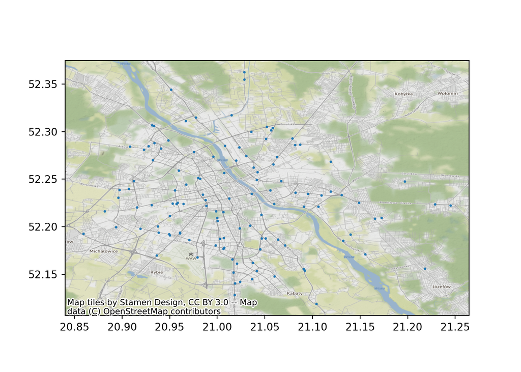

Figure 1. Map

```python
import pandas as pd
import geopandas
import matplotlib.pyplot as plt
import contextily
pop_df_warsaw = pd.read_csv("pop_df_warsaw.csv")
df = pd.read_csv("dane.csv")
pop_df_warsaw = geopandas.GeoDataFrame(pop_df_warsaw, geometry=geopandas.points_from_xy(pop_df_warsaw.SHAPE_Leng, pop_df_warsaw.SHAPE_Area), crs='epsg:3035')
stacje = geopandas.GeoDataFrame(df, geometry=geopandas.points_from_xy(df.x, df.y), crs='epsg:4326')
ax = stacje.plot(markersize=2)
contextily.add_basemap(ax, crs=stacje.crs.to_string())
plt.show()
```

The distribution of the average traffic volume and the basic descriptive statistics allow us to notice a clear variation in traffic volume between stations. The station with the most traffic has twice as many average customers per week as the station with the least traffic.

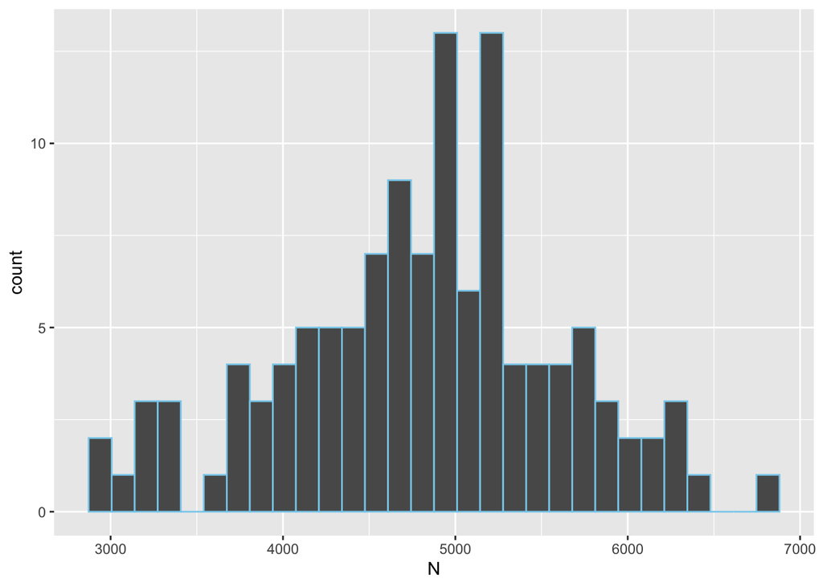

Figure 2. Distribution of the average number of customers at stations in Warsaw

```r
ggplot(data = dane, aes(x = N)) +
  geom_histogram(position = 'stack', aes(y = ..count..), color='skyblue')
```

Variables describing spatial relationships between points will be used for the model. These include the following characteristics: *number of neighboring stations within 5 and 10 km, average distance from the nearest arterial road, average distance from the nearest exit road, distance from the center, distance from the nearest neighboring station. Variables were aggregated at different levels (min, max, mean, median) to compare different types of interactions between points.* The distances given are measured in km, but not in a straight line, but by the shortest access route determined by OSM. For comparison, the length of Warsaw to the west is 28 km.

```r
modelformula <- ruch ~ x + y+ min_odl_trunk + max_odl_trunk +
avg_odl_trunk + min_odl_primary + max_odl_primary + avg_odl_primary + od_centrum +
od_stacji_min + od_stacji_max + ile_stacji_r5 + ile_stacji_r10
modelformula
```

```
## ruch ~ x + y + min_odl_trunk + max_odl_trunk + avg_odl_trunk +
##     min_odl_primary + max_odl_primary + avg_odl_primary + od_centrum +
##     od_stacji_min + od_stacji_max + ile_stacji_r5 + ile_stacji_r10
```

There are 120 stations in Warsaw belonging to 5 different networks and with different service and location characteristics. Within a 5 km radius, the average number of neighboring stations is 3.5, while within a 10 km radius, the average is 20 stations. There are points that are located in such a way that they have no neighbor at all within a 5 km radius and at most one within a 10 km radius. In places with the highest density, up to 8 stations are located within 5 km, and up to 43 stations within 10 km. On the other hand, the closest points are located only 600 m from each other. On average, they are 3 km apart, and the farthest distance between points is 8.6 km. Analyzing the data for the average distance from the nearest arterial road and exit road, the average distances are 20 km and 38 km, respectively. 25% of the gas stations are located 1.2 km from the nearest arterial and 4 km from the nearest exit road, while 75% are located 5 and 10 km away.

# 2. Kriging

There are several definitions of this technique, although the most accurate was given by Krige (1981) for metal ores: “a multiple regression procedure for obtaining the best linear unweighted prediction or the best linearly weighted moving average predictor of an ore deposit (of any size) by assigning an optimal set of weights to all available and relevant data inside and outside the ore block.”

Splitting the dataset into training and testing parts, without considering spatial autocorrelation and spatial sampling of the dataset.

```r
set.seed(1234)
dane.sp$r<-runif(dim(dane.sp)[1])
input <- dane.sp[dane.sp$r<0.8, ] # wybranie 80% danych na zbiór treningowy
output <- dane.sp[dane.sp$r>0.8, ]
```

## Ordinary kriging

Ordinary kriging assumes that the mean value is unknown across the study region.

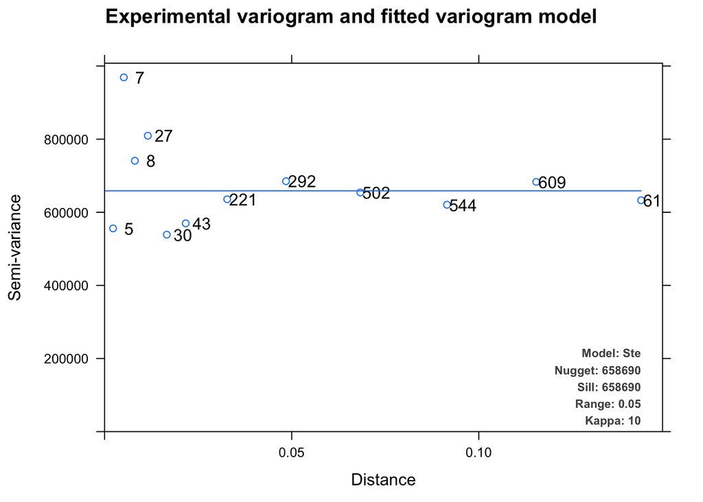

Figure 3. Variogram for the kriging models.

```r
# zwykły kriging (ordinary kriging)
set.seed(1234)
ok.var<- autofitVariogram(ruch~1, input)
plot(ok.var)
```

```r
## zwykły kriging
set.seed(1234)
ok.xy <- autoKrige(ruch~1, input, output, verbose=FALSE, model = c("Sph", "Exp", "Gau", "Ste"), kappa = c(0.05, seq(0.2, 2, 0.1), 5, 10))
```

```
## [using ordinary kriging]
```

## Universal kriging

```r
# uniwersalny kriging oparty na funkcji współrzędnych Kartezjańskich
set.seed(1234)
uk.var.1 <- autofitVariogram(ruch~x+y+ min_odl_trunk + max_odl_trunk +
avg_odl_trunk + min_odl_primary + max_odl_primary + avg_odl_primary + od_centrum +
od_stacji_min + od_stacji_max + ile_stacji_r5 + ile_stacji_r10, input)
## uniwersalny kriging, x+y
set.seed(1234)
uk.xy <- autoKrige(ruch~x+y+ min_odl_trunk + max_odl_trunk +
avg_odl_trunk + min_odl_primary + max_odl_primary + avg_odl_primary + od_centrum +
od_stacji_min + od_stacji_max + ile_stacji_r5 + ile_stacji_r10, input, output, verbose=FALSE, model = c("Sph", "Exp", "Gau", "Ste"), kappa = c(0.05, seq(0.5, 10, 5), 5, 10))
```

```
## [using universal kriging]
```

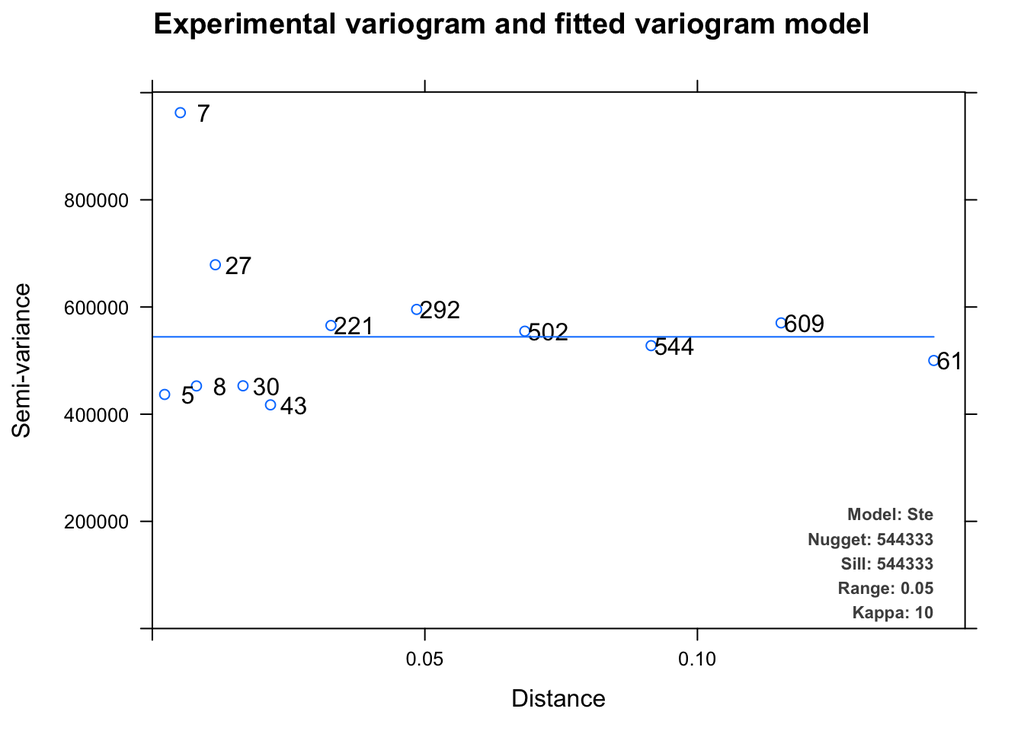

Figure 4. Variograms for the kriging models.

```r
plot(uk.var.1)
```

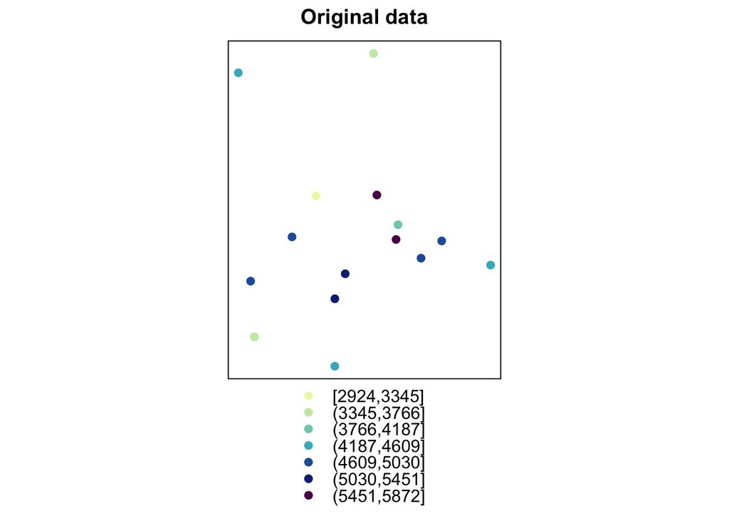

```r
## original values
result0<-automapPlot(output, "ruch", main="Original data")
result0
```

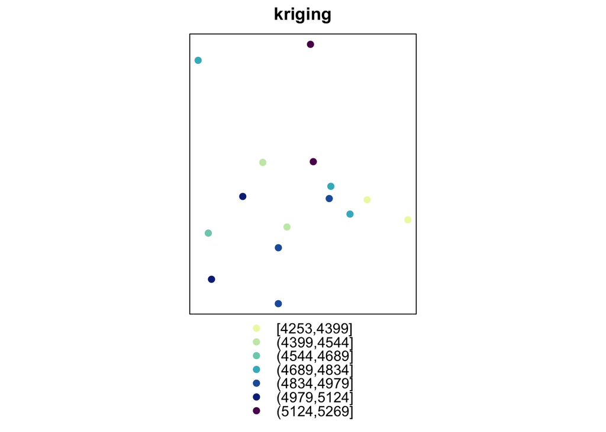

```r
## ordinary
par(mfrow=c(1,2))
#result1<-automapPlot(ok.xy$krige_output, "var1.pred", main="Ordinary
#kriging")
#result1
## universal, x+y
result2<-automapPlot(uk.xy$krige_output, "var1.pred", main="kriging")
result2
```

```r
rmse_ord <- rmse(output$ruch, ok.xy$krige_output@data$var1.pred)
rmse_un_xy <- rmse(output$ruch, uk.xy$krige_output@data$var1.pred)
```

# 3. Non- spatial ML

Another method that was used for the study was the random forest model. The model without considering the spatial nature of the variables will be the first to be estimated.

```r
set.seed(1234)
mtry <- sqrt(ncol(dane))
random.forest_basic <- randomForest(modelformula,
                                    data = train,
                                    ntree = 300,
                                    #sampsize = 50,
                                    mtry = mtry,
                                    importance = TRUE)
print(random.forest_basic)
```

```
##
## Call:
##  randomForest(formula = modelformula, data = train, ntree = 300,      mtry = mtry, importance = TRUE)
##                Type of random forest: regression
##                      Number of trees: 300
## No. of variables tried at each split: 6
##
##           Mean of squared residuals: 719551.3
##                     % Var explained: -13.82
```

```r
a = regressionMetrics(real = test$ruch,
                  predicted = predict(random.forest_basic, test))
kable(a, align = "cc", caption = "Table. Metrics for the basic model") %>% kable_styling(bootstrap_options = c("striped", "hover"))
```

Table. Metrics for the basic model

| MSE | RMSE | MAE | MedAE | MSLE |
| --- | --- | --- | --- | --- |
| 606476.1 | 778.7658 | 580.6268 | 400.23 | 0.0342667 |

## The use of cross-validation and optimization of hyperparameters

*The role of cross-validation is:* 1) estimation of prediction error, 2) detection of model overfitting 3) hyperparameter tuning (mainly in machine learning models).

There are different methods for splitting data into training and test data in cross-validation. The most common one is called k-fold crossvalidation. It consists in randomly dividing the sample into k subsamples (usually k=5 in small samples and k=10 in large samples) and running the model k times on k-1 samples, leaving in each iteration 1 subsample as the validation set (different in each of k iterations). In this way, each observation is in the validation set once and k-1 times in the training set.

In this case, mtry parameters from 1 to 15 and the following number of trees will be checked: 50,100,150,300,450,600.

```r
control <- trainControl(method="repeatedcv", number=5, repeats=3, search="random")

tunegrid <- expand.grid(.mtry=c(1:15),
                        .ntree=c(50,100,150,300,450,600))

customRF <- list(type = "Regression", library = "randomForest", loop = NULL)
customRF$parameters <- data.frame(parameter = c("mtry", "ntree"), class = rep("numeric", 2), label = c("mtry", "ntree"))
customRF$grid <- function(x, y, len = NULL, search = "grid") {}
customRF$fit <- function(x, y, wts, param, lev, last, weights, classProbs, ...) {
  randomForest(x, y, mtry = param$mtry, ntree=param$ntree, ...)
}
customRF$predict <- function(modelFit, newdata, preProc = NULL, submodels = NULL)
   predict(modelFit, newdata)
customRF$prob <- function(modelFit, newdata, preProc = NULL, submodels = NULL)
   predict(modelFit, newdata, type = "prob")

set.seed(1234)
random.forest_2 <-
  train(modelformula,
        data = train,
        method= customRF,
        tuneGrid=tunegrid,
        trControl=control)

print(random.forest_2)
```

```
## 88 samples
## 13 predictors
##
## No pre-processing
## Resampling: Cross-Validated (5 fold, repeated 3 times)
## Summary of sample sizes: 70, 72, 70, 70, 70, 71, ...
## Resampling results across tuning parameters:
##
##   mtry  ntree  RMSE      Rsquared    MAE
##    1     50    817.9947  0.06260028  624.5294
##    1    100    819.5531  0.07159301  626.6149
##    1    150    815.9167  0.05458126  618.5596
##    1    300    821.9370  0.05362552  624.0221
##    1    450    822.0238  0.05812455  624.8477
##    1    600    819.8520  0.05373634  621.7284
```

[output cut: 87 more lines]

The smallest prediction errors are obtained for the parameter mtry equal to 1 and for the number of trees equal to 150.

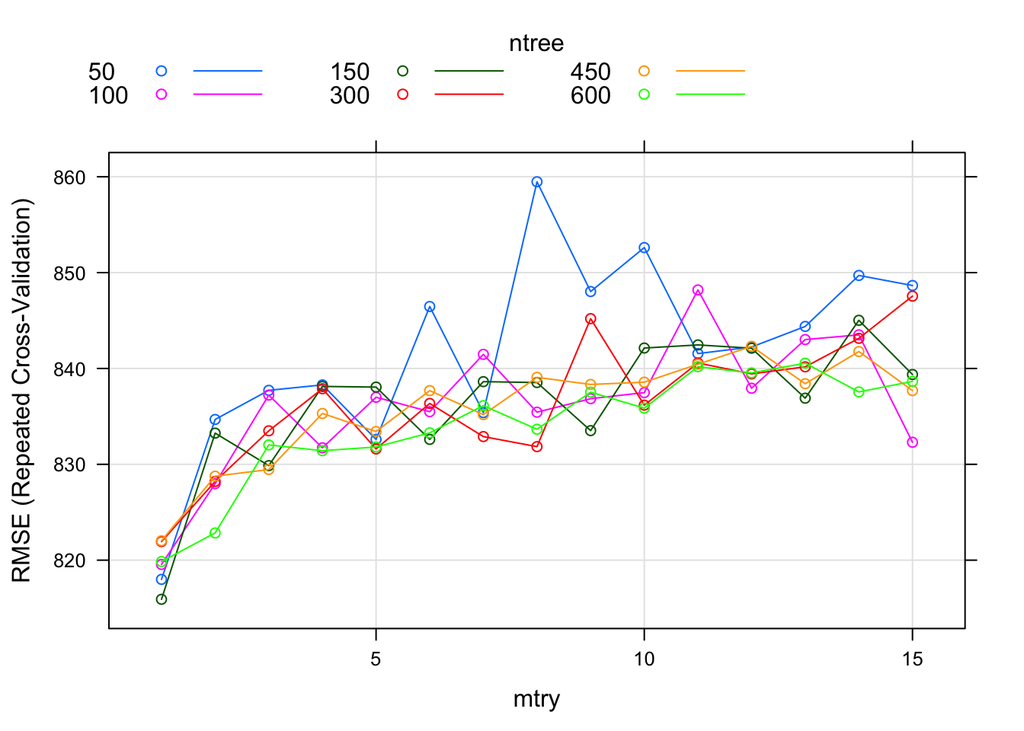

Figure 4. Models results.

```r
plot(random.forest_2)
```

```r
set.seed(1234)
random.forest <- randomForest(modelformula,
                                    data = train,
                                    ntree = random.forest_2$bestTune$ntree,
                                    sampsize=60,
                                    mtry = random.forest_2$bestTune$mtry,
                                    importance = TRUE)
print(random.forest)
```

```
##
## Call:
##  randomForest(formula = modelformula, data = train, ntree = random.forest_2$bestTune$ntree,      sampsize = 60, mtry = random.forest_2$bestTune$mtry, importance = TRUE)
##                Type of random forest: regression
##                      Number of trees: 150
## No. of variables tried at each split: 1
##
##           Mean of squared residuals: 668138.2
##                     % Var explained: -5.69
```

The prediction error values on the test set for the model after hyperparameter optimization are shown in the table below.

```r
b = regressionMetrics(real = test$ruch,
                  predicted = predict(random.forest, test))
kable(b, align = "cc", caption = "Table. Metrics for the model after hyperparameter optimization") %>% kable_styling(bootstrap_options = c("striped", "hover"))
```

Table. Metrics for the model after hyperparameter optimization

| MSE | RMSE | MAE | MedAE | MSLE |
| --- | --- | --- | --- | --- |
| 537826.1 | 733.3662 | 539.6608 | 272.2485 | 0.0310093 |

# 4. Spatial ML

The results of a cross-validation procedure using spatial sampling can be easily obtained from the sperrorest() function. The names of the columns containing the spatial coordinates needed to implement spatial sampling are defined using a text vector in the coords argument.

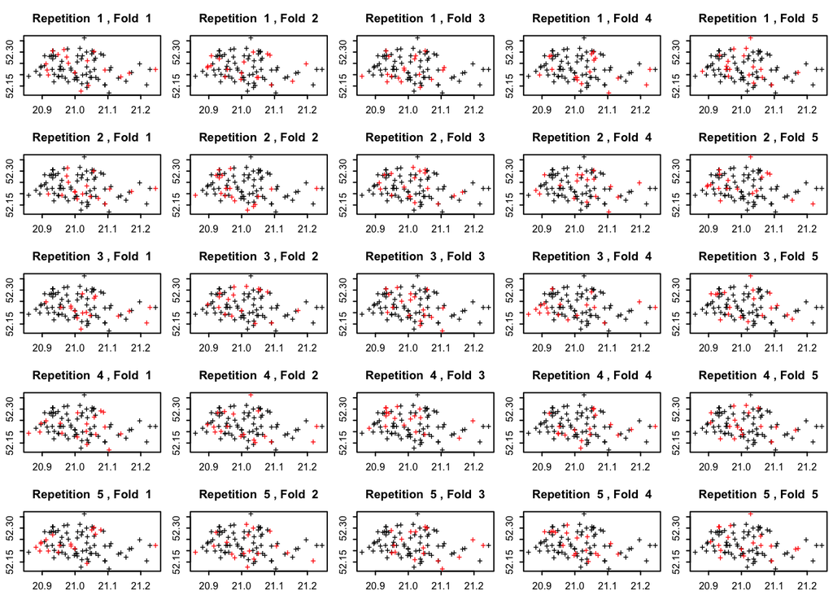

```r
resamp<-partition_cv(train, nfold=5, repetition=5, seed1=1)
plot(resamp, train, coords = c("x","y"))
```

Estimates for block sampling based on k-means are presented below. In this sampling scheme, k spatial blocks of observations with average counts n/k (where k is the number of folds and n is the number of observations) are determined based on the kmeans algorithm. Their characteristic is the spatial clustering of observations. Then k-1 folds form the training set, and the kth spatially homogeneous cluster is the test set.

```r
set.seed(1234)
res_rf_kmeans<-sperrorest(modelformula, data=dane,
                          coords = c("x", "y"),
                          model_fun=randomForest,
                          model_args=list(ntree=random.forest_2$bestTune$ntree, mtry=random.forest_2$bestTune$mtry),
                          smp_fun=partition_kmeans,
                          progres='all',
                          smp_args=list(repetition=1:5, nfold=5, seed1=1234))
spatial_ml_rmse= res_rf_kmeans$error_rep$test_rmse
```

# 5. Summary

```r
model= c("ordinary kriging", "universal kriging", "non spatial random forest - basic", "non spatial random forest - tuned", "spatial random forest")
rmse= c(round(rmse_ord,2), round(rmse_un_xy,2), round(a$RMSE,2), round(b$RMSE,2), round(spatial_ml_rmse,2))
table = as.data.frame(cbind(model, rmse))
table$rmse= as.numeric(table$rmse)
table=table %>% arrange(rmse)
kable(table, align = "cc", caption = "Table. RMSE error values for each model on the test set") %>% kable_styling(bootstrap_options = c("striped", "hover"))
```

Table. RMSE error values for each model on the test set

| model | rmse |
| --- | --- |
| spatial random forest | 730.10 |
| non spatial random forest - tuned | 733.37 |
| universal kriging | 769.10 |
| ordinary kriging | 777.83 |
| non spatial random forest - basic | 778.77 |

# 6. Comparison with study results